# R2

RA ([numpde](https://github.com/numpde/))

2021-03-25

## Preliminaries

### Introduction

Tools: [scater](https://bioconductor.org/packages/3.12/bioc/vignettes/scater/inst/doc/overview.html), [SingleCellExperiment](http://bioconductor.org/packages/release/bioc/html/SingleCellExperiment.html), [igraph](https://nbisweden.github.io/single-cell_sib_scilifelab/session-clustering/clustering.html), [DESeq2](https://bioconductor.org/packages/release/bioc/vignettes/DESeq2/inst/doc/DESeq2.html), etc.

### Setup

```r
suppressPackageStartupMessages({
  # install.packages("kableExtra")
  requireNamespace("kableExtra")

  # install.packages("crunch")
  requireNamespace("crunch")

  # https://rstudio.github.io/DT/
  # install.packages("DT")
  requireNamespace("DT")

  # may need to say "don't restart session"
  # install.packages("RCurl")
  requireNamespace("RCurl")

  # install.packages("dplyr")
  library(dplyr)
  # install.packages("ggplot2")
  library(ggplot2)

  #
  requireNamespace("tidyr")

  # BiocManager::install("org.Mm.eg.db")
  requireNamespace("org.Mm.eg.db")

  # https://www.bioconductor.org/packages/release/bioc/vignettes/goseq/inst/doc/goseq.pdf
  # BiocManager::install("goseq")
  requireNamespace("goseq")

  # https://vroom.r-lib.org/articles/vroom.html
  # install.packages("vroom")
  requireNamespace("vroom")

  # BiocManager::install("DESeq2")
  requireNamespace("DESeq2")

  # BiocManager::install("scater")
  requireNamespace("scater")

  # BiocManager::install("scran")
  requireNamespace("scran")

  # BiocManager::install("igraph")
  requireNamespace("igraph")

  # install.packages("pheatmap")
  requireNamespace("pheatmap")
  # install.packages("stringr")
  requireNamespace("stringr")
  # install.packages("reshape2")
  requireNamespace("reshape2")
  # install.packages("pathlibr")
  requireNamespace("pathlibr")
  # install.packages("pbapply")
  requireNamespace("pbapply")

  # install.packages("Rtsne")
  requireNamespace("Rtsne")
  # install.packages("uwot")
  requireNamespace("uwot")

  # avoid importing `exprs` that leads to clashes
  requireNamespace("rlang")
})
```

[output not shown]

[output not shown]

[output not shown]

[output not shown]

[output not shown]

[output not shown]

[output not shown]

[output not shown]

[output not shown]

[output not shown]

[output not shown]

[output not shown]

[output not shown]

[output not shown]

[output not shown]

[output not shown]

[output not shown]

[output not shown]

[output not shown]

[output not shown]

[output not shown]

[output not shown]

[output not shown]

[output not shown]

[output not shown]

[output not shown]

[output not shown]

[output not shown]

[output not shown]

[output not shown]

[output not shown]

[output not shown]

[output not shown]

[output not shown]

[output not shown]

[output not shown]

[output not shown]

[output not shown]

[output not shown]

[output not shown]

[output not shown]

[output not shown]

[output not shown]

[output not shown]

[output not shown]

[output not shown]

[output not shown]

[output not shown]

[output not shown]

[output not shown]

[output not shown]

[output not shown]

[output not shown]

[output not shown]

[output not shown]

[output not shown]

[output not shown]

[output not shown]

[output not shown]

[output not shown]

[output not shown]

[output not shown]

[output not shown]

[output not shown]

[output not shown]

[output not shown]

[output not shown]

### Paths

```r
BASEPATH <- pathlibr::Path$new(".")
stopifnot("main.Rmd" %in% names(BASEPATH$dir))
```

```r
path_to <- (function(.) Sys.glob(BASEPATH$join("../..")$join(.)$show))
```

### Plotting

```r
ggplot2::theme_set(theme_light(base_size = 15))
```

```r
kable <- function(.) {
  kableExtra::kbl(., align = "c") %>%
    kableExtra::kable_paper("hover", full_width = F)
}
```

```r
options(DT.options = list(
  pageLength = 16,
  language = list(search = "Filter:")
))
```

```r
link <-
  function(x) {
    dplyr::case_when(
      # If x is like GO:003453
      startsWith(x, "GO:") ~ paste0(
        "<a target='_blank'",
        "href='", "http://amigo.geneontology.org/amigo/term/", x, "'",
        ">", x, "</a>"
      ),
      # Otherwise try this
      TRUE ~ paste0(
        "<a target='_blank'",
        "href='", "http://www.informatics.jax.org/marker/summary?nomen=", x, "'",
        ">", x, "</a>"
      )
    )
  }
```

### Dataframes

```r
# Use first column as index
by_col1 <- (function(.) tibble::column_to_rownames(., colnames(.)[1]))
# Use index as new column `name`
ind2col <- (function(., name) tibble::rownames_to_column(., var = name))
```

```r
arrange.like <- (function(X, T) X[rownames(T), , drop = FALSE])
rows.of <- (function(rows, X) X[rows, , drop = FALSE])
```

```r
Sys.setenv("VROOM_CONNECTION_SIZE" = 131072 * 4)
from_csv <- function(.) {
  vroom::vroom(., del = "\t", progress = FALSE) %>%
    by_col1() %>%
    suppressMessages()
}
```

### Misc

```r
# Wrap functions that do `library(...)`
# and force-detach all attached packages
unattach_packages <- function(f) {
  # install.packages("crunch")
  requireNamespace("crunch")

  # wrapper for f
  function(...) {
    base::with(
      crunch::ContextManager(
        enter = base::search,
        exit = function() {
          for (pkg in setdiff(base::search(), enter)) {
            base::detach(pkg, character.only = TRUE, force = TRUE)
          }
        },
        # this overwrites the variable `enter`, if existent
        as = "enter"
      ),
      {
        f(...)
      }
    )
  }
}

# Usage:
# unattach_packages(function(x, y) { library(goseq); x + y })(1, 2)
```

## Datasets

### Notes

–

### Transcript info

```r
tx <- list(
  # Mouse
  mm = merge(
    (
      # https://doi.org/doi:10.18129/B9.bioc.org.Mm.eg.db
      org.Mm.eg.db::org.Mm.egSYMBOL2EG
    ),
    (
      TxDb.Mmusculus.UCSC.mm39.refGene::TxDb.Mmusculus.UCSC.mm39.refGene %>%
        GenomicFeatures::transcriptLengths() %>%
        dplyr::group_by(gene_id) %>%
        dplyr::summarize(tx_len = median(tx_len))
    ),
    by = "gene_id"
  )
  # data.frame with transcript lengths
  # (gene_id is unique, symbol is not)
  #     gene_id        symbol avg_tx_len
  # 1 100009600         Zglp1       1010
  # 2 100009609       Vmn2r65       2538
  # 3 100009614       Gm10024        564
  # etc.
) %>% lapply(
  # Reindex by symbol
  function(.) {
    (.) %>%
      dplyr::group_by(symbol) %>%
      dplyr::summarize(tx_len = median(tx_len)) %>%
      by_col1()
  }
)
```

### Gene sets

```r
# C7: immunologic signature gene sets
# http://www.gsea-msigdb.org/gsea/msigdb/collections.jsp
# ported to Mus musculus:
# http://bioinf.wehi.edu.au/MSigDB/index.html
```

### AB – Mouse ctx & hip (10x)

#### Load

The whole [mouse wc&h](https://portal.brain-map.org/atlases-and-data/rnaseq/mouse-whole-cortex-and-hippocampus-10x) dataset has 1M cells x 50k genes. We have restricted it to certain cell-types.

```r
sce_abm_ch <-
  SingleCellExperiment::SingleCellExperiment(
    assays = list(
      counts = (
        path_to("*/AllenBrain/Mouse-WCH*/*fewer_cells/data.*.gz") %>%
          from_csv() %>%
          `[`(, sort(colnames(.))) %>%
          # conversion to matrix takes longest
          # but is necessary for some operations below
          as.matrix()
      )
    ),
    colData = (
      path_to("*/AllenBrain/Mouse-WCH*/f*cells/meta.*.gz") %>%
        from_csv() %>%
        `[`(sort(rownames(.)), )
    )
  ) %>%
  # Order by cell type: sometimes convenient below
  `[`(, order((.)$cell_type_alias_label))
```

To reduce the memory footprint, only keep recognized genes.

```r
sce_abm_ch <-
  sce_abm_ch %>%
  `[`(sort(intersect(rownames(.), rownames(tx$mm))), )
```

Attach a “Is VLMC” flag to samples.

```r
sce_abm_ch$subclass_label <-
  sce_abm_ch$subclass_label %>%
  as.factor() %>%
  relevel(ref = "VLMC")

sce_abm_ch$is_vlmc <-
  sce_abm_ch$subclass_label %>%
  magrittr::equals("VLMC")
```

#### Cell types

```r
exclude_celltypes <- c("Astro", "Endo")
```

[output not shown]

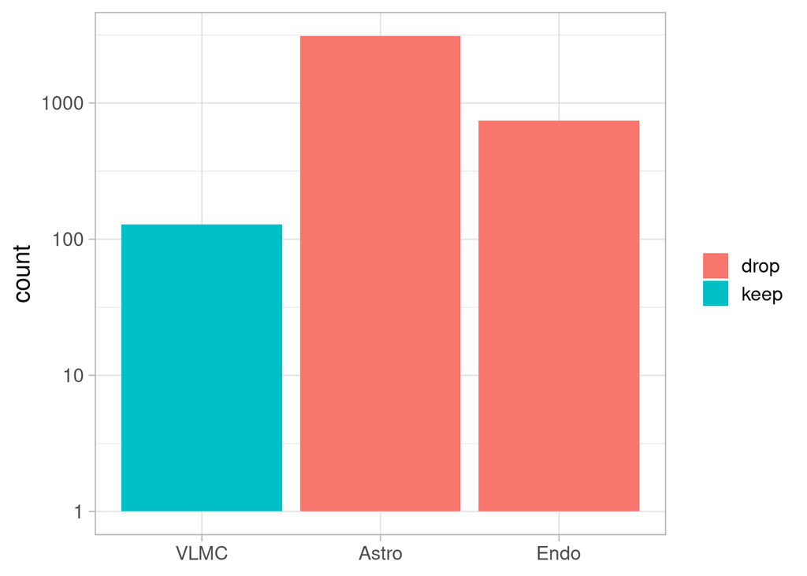

```r
sce_abm_ch$subclass_label %>%
  data.frame(x = .) %>%
  ggplot() +
  aes(x = x, fill = if_else(x %in% exclude_celltypes, "drop", "keep")) +
  geom_bar() +
  scale_y_log10() +
  # hist_theme +
  theme(
    axis.title.x = element_blank(),
    axis.text.x = element_text(a = 0, hjust = 0.5),
    legend.title = element_blank(),
  )
```

#### Diagnostics

Attach diagnostics by scater.

```r
sce_abm_ch <-
  sce_abm_ch %>%
  {
    scater::addPerCellQC(
      x = (.),
      subsets = list(Mito = grep("mt-", rownames(.)))
    )
  } %>%
  # Used for the heatmap
  scater::logNormCounts() %>%
  # Not all are used further below:
  scater::runPCA(name = "PCA", ncomponents = 20) %>%
  # scater::runTSNE(perplexity = 10, dimred = "PCA") %>%
  scater::runUMAP()
```

Samples with fewer than 1000 counts have been [discarded](https://portal.brain-map.org/atlases-and-data/rnaseq/protocols-mouse-cortex-and-hippocampus#gene_expression_quantification).

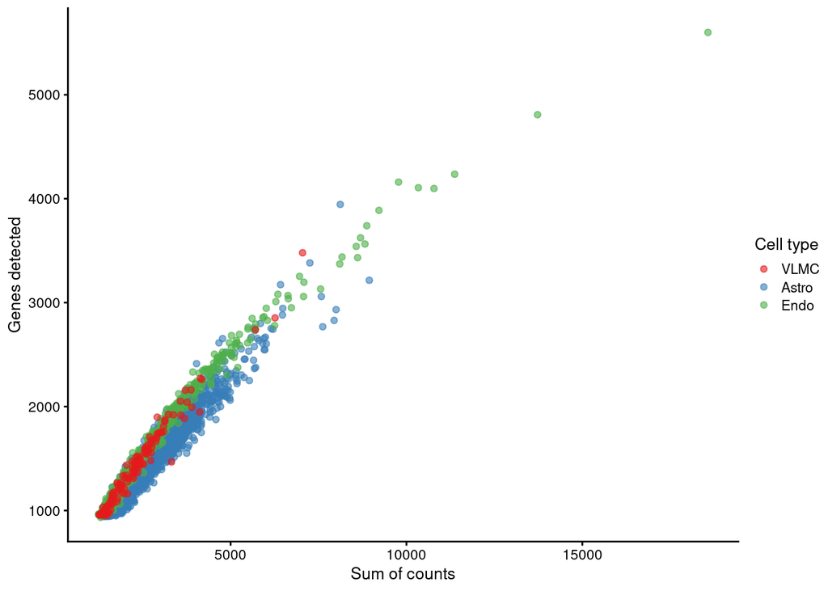

```r
sce_abm_ch %>%
  `[`(, order((.)$cell_type_alias_label)) %>%
  scater::plotColData(
    x = "sum",
    y = "detected",
    colour_by = "subclass_label"
  ) +
  labs(x = "Sum of counts", y = "Genes detected") +
  scale_color_brewer(palette = "Set1", name = "Cell type")
```

Each bar corresponds to a cell:

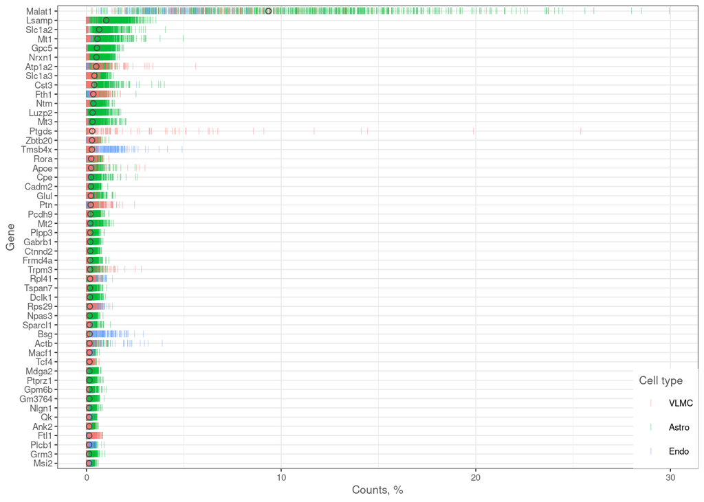

```r
sce_abm_ch %>%
  # Subsample for expediency
  `[`(, union((1:ncol(.))[(.)$is_vlmc], sample(1:ncol(.), 777))) %>%
  # Plot in the right order for (some) visibility
  `[`(, order((.)$cell_type_alias_label)) %>%
  scater::plotHighestExprs(
    exprs_values = "counts",
    colour_cells_by = "subclass_label",
    as_percentage = TRUE
  ) +
  scale_color_discrete(name = "Cell type") +
  labs(x = "Counts, %", y = "Gene")
```

## Analysis – Mouse

### Overview

The cells cluster by cell type.

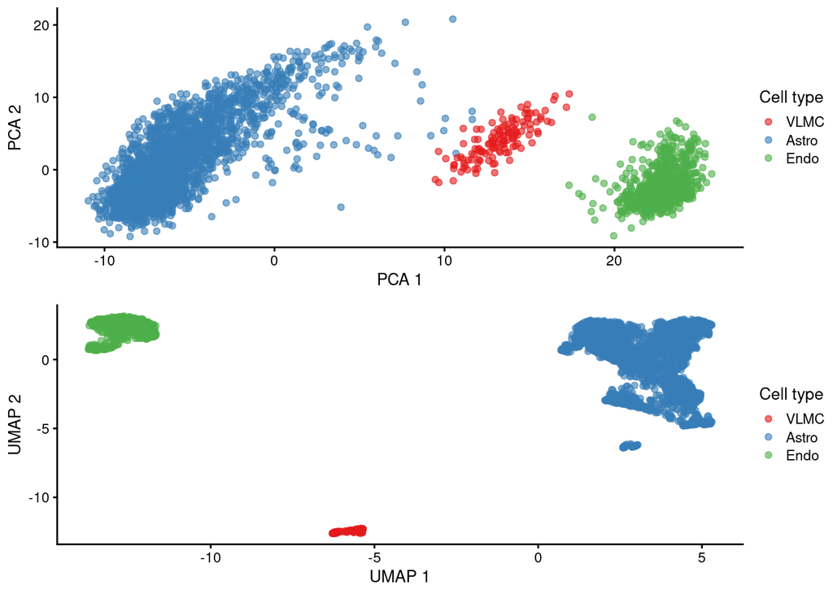

```r
sce_abm_ch %>%
  # Plot in the right order
  `[`(, order((.)$cell_type_alias_label)) %>%
  {
    function(which_dimred) {
      scater::plotReducedDim(
        dimred = which_dimred,
        object = (.),
        colour_by = "subclass_label"
        # colour_by = "cell_type_alias_label"
      ) +
        # theme(legend.position = "none") +
        scale_color_brewer(palette = "Set1", name = "Cell type")

      # The colors that come with the dataset are all grey:
      # scale_color_manual(values = c("#3B3F32", "#697255", "#535944"))
    }
  } %>%
  {
    gridExtra::grid.arrange((.)("PCA"), (.)("UMAP"), nrow = 2)
  }
```

### VLMC vs Other

Before focusing on the VLMC cells, we check for differential genes of VLMC vs the rest. We take a subsample of cells for expedience.

```r
# This does not modify the original:
# sce_abm_ch %>% list(sce = .) %>% within({sce$dummy <- 2})

de_results.ctrl_vs_vlmc <-
  sce_abm_ch %>%
  list(sce = .) %>%
  within({
    # SUBSAMPLE:
    # Take VLMC and sample some from the rest

    jj <- 1:ncol(sce)

    set.seed(15)
    jj_vlmc <- jj[sce$is_vlmc]
    jj_ctrl <- jj[!sce$is_vlmc] %>% sample(3 * length(jj_vlmc))

    sce <- sce[, union(jj_vlmc, jj_ctrl)]

    # Intermediate report (facultative)
    sce$subclass_label %>%
      table() %>%
      print()
  }) %>%
  with({
    sce %>%
      # Package into DESeq object; DE between VLMC and Other
      DESeq2::DESeqDataSet(design = ~is_vlmc) %>%
      DESeq2::estimateSizeFactors() %>%
      DESeq2::DESeq(quiet = TRUE, fitType = "local") %>%
      DESeq2::results()
  }) %>%
  as.data.frame() %>%
  slice_min(pvalue, n = 500)
```

```
## .
##  VLMC Astro  Endo
##   129   317    70
```

```r
de_results.ctrl_vs_vlmc %>%
  select(mean = baseMean, l2fc = log2FoldChange, p = pvalue, padj) %>%
  ind2col("symbol") %>%
  mutate(symbol = link(symbol)) %>%
  DT::datatable(escape = FALSE) %>%
  DT::formatSignif(c("mean", "l2fc", "p", "padj"), digits = 3)
```

|  | symbol | mean | l2fc | p | padj |
| --- | --- | --- | --- | --- | --- |
| 1 | Apod | 5.22359907732591 | 6.53374367176396 | 4.65927873530634e-186 | 1.70762565648978e-182 |
| 2 | Cped1 | 1.76271728221243 | 4.65558039461904 | 2.26483725929135e-144 | 4.1503142776514e-141 |
| 3 | Gpc5 | 9.83723846838917 | -5.81858602141494 | 1.608910908944e-135 | 1.96555282709325e-132 |
| 4 | Lsamp | 19.581271450072 | -5.52333871770018 | 1.17889595995568e-128 | 1.08016342330939e-125 |
| 5 | Nupr1 | 1.75069343977639 | 4.56685659784393 | 1.14002413591276e-123 | 8.35637691624052e-121 |
| 6 | Slc1a2 | 18.7759172730952 | -6.25518214649344 | 3.21656284132968e-123 | 1.96478380224555e-120 |
| 7 | Nrxn1 | 10.0382247740913 | -4.62223647544365 | 1.74545894053636e-104 | 9.13872431009394e-102 |
| 8 | Slc7a11 | 4.02438496150337 | 3.57627787154395 | 1.88353374932361e-102 | 8.6289389890888e-100 |
| 9 | Colec12 | 1.30494668267474 | 4.37828368426085 | 4.94240744508247e-101 | 2.01265814291414e-98 |
| 10 | Ptgds | 22.3562924867966 | 8.97206473526542 | 7.87881178026163e-92 | 2.88758451746589e-89 |

[output cut: 490 more lines]

Establish a color scheme for the following.

```r
annotation_colors <-
  sce_abm_ch %>% {
    # This defines annotation colors
    list(
      # Create colors for the given cell types
      subclass_label = (
        (.)$subclass_label %>%
          unique() %>%
          sort(decreasing = FALSE) %>%
          list(
            x = .,
            c = RColorBrewer::brewer.pal(n = length(.), name = "Set1")
          )
      ),

      # Create colors for the given cell sub types
      cell_type_alias_label = (
        (.)$cell_type_alias_label %>%
          unique() %>%
          list(
            x = .,
            c = RColorBrewer::brewer.pal(n = length(.), name = "Spectral")
          )
      ),

      # Use the given colors for the brain anatomical region
      region_label = data.frame(
        x = (.)$region_label,
        c = (.)$region_color
      ) %>% unique()
    ) %>%
      lapply(function(.) {
        (.) %>%
          as.data.frame() %>%
          pull(c, x) %>%
          unlist()
      })
  }
```

Heatmap of those DE genes for all cells. Clustering of samples using topmost DE genes does collect the VLMC cells together:

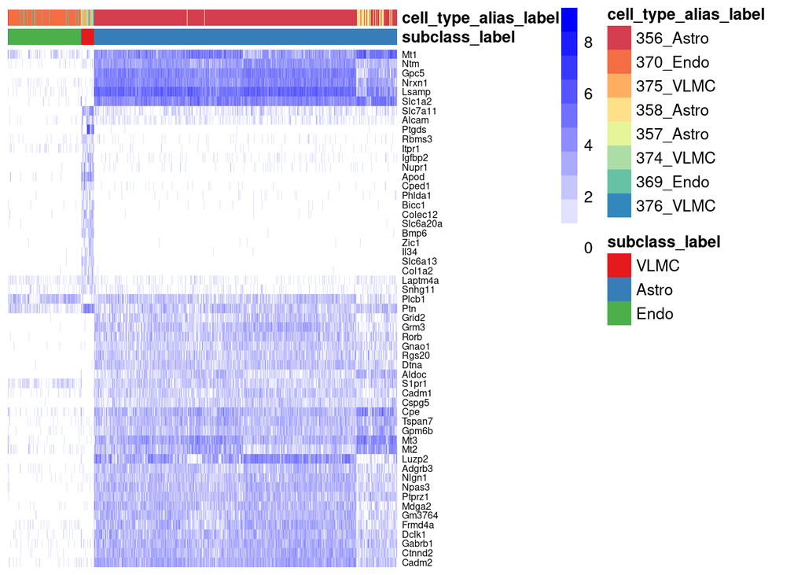

```r
de_results.ctrl_vs_vlmc %>%
  slice_min(pvalue, n = 55, with_ties = TRUE) %>%
  rownames() %>%
  rows.of(sce_abm_ch) %>%
  scater::logNormCounts() %>%
  # Order columns by cell type
  `[`(, order((.)$cell_type_alias_label)) %>%
  {
    pheatmap::pheatmap(
      mat = (
        (.)@assays@data$logcounts
      ),
      annotation_col = (
        (.)@colData %>%
          as.data.frame() %>%
          dplyr::select(subclass_label, cell_type_alias_label)
      ),
      cluster_cols = TRUE, # (!)
      show_colnames = FALSE,
      fontsize_row = 6,
      treeheight_row = 0,
      treeheight_col = 0,
      color = grDevices::colorRampPalette(c("white", "blue"))(10),
      annotation_colors = annotation_colors
    )
  }
```

Let’s look at the genes that are identified as markers in the “betsholtzlab dataset”. Some astrocytes invade the VLMC cluster.

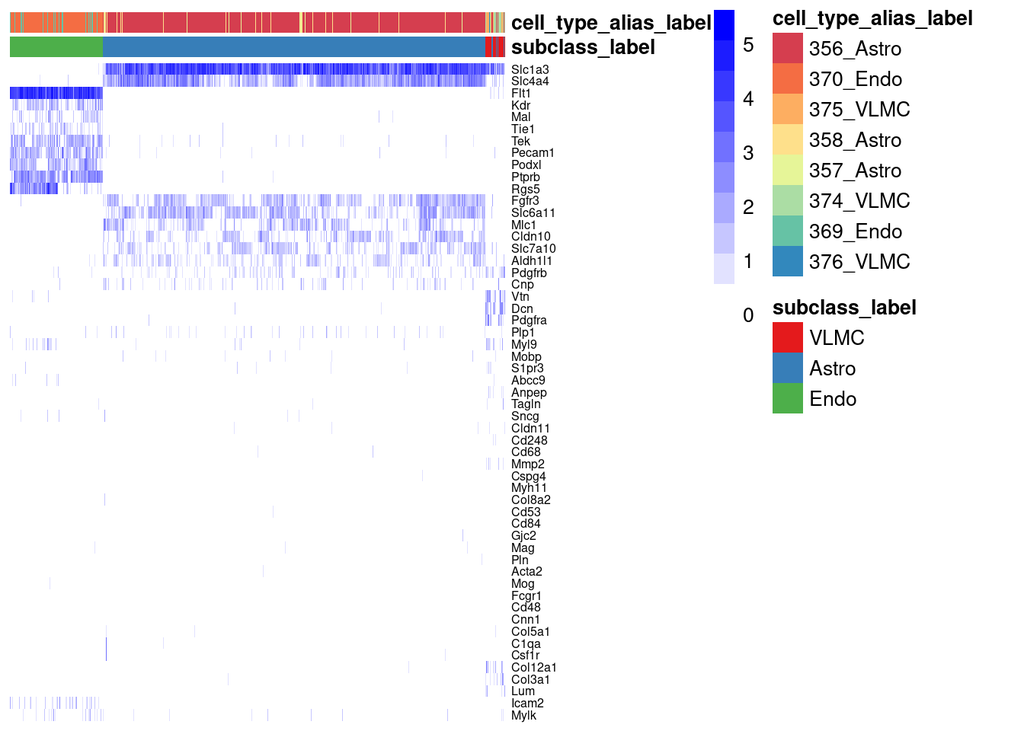

```r
sce_abm_ch %>%
  `[`(
    intersect(
      rownames(.),
      rownames(from_csv(path_to("*/Betsholtz-2018/*/mrkr.*")))
    ),
  ) %>%
  {
    pheatmap::pheatmap(
      mat = (
        (.)@assays@data$logcounts
      ),
      annotation_col = (
        (.)@colData %>%
          as.data.frame() %>%
          dplyr::select(subclass_label, cell_type_alias_label)
      ),
      cluster_cols = TRUE, # (!)
      show_colnames = FALSE,
      fontsize_row = 6,
      treeheight_row = 0,
      treeheight_col = 0,
      color = grDevices::colorRampPalette(c("white", "blue"))(10),
      annotation_colors = annotation_colors
    )
  }
```

### Filter for VLMC

```r
sce_abm_ch.vlmc <-
  sce_abm_ch %>%
  `[`(, (.)$is_vlmc)
```

### Cluster within VLMC

UMAP roughly reflects the cell subtypes provided with the data.

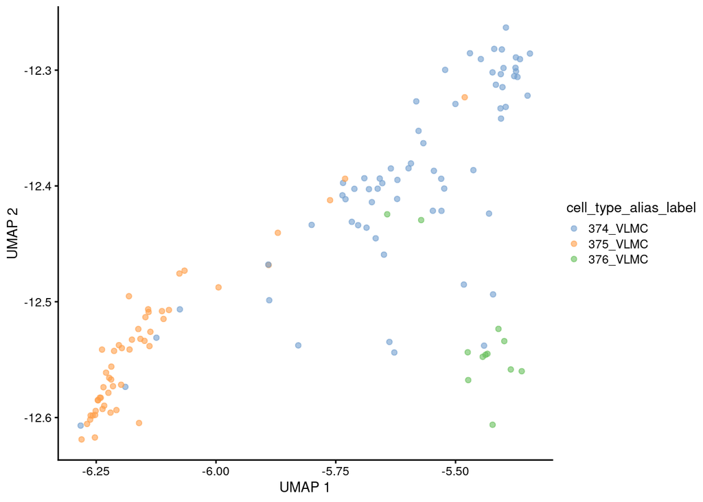

```r
sce_abm_ch.vlmc %>%
  scater::plotReducedDim(dimred = "UMAP", colour_by = "cell_type_alias_label")
```

We wish to capture exactly two clusters for DE analysis. The subsequent analysis assumes this.

```r
sce_abm_ch.vlmc$my_cluster_label <-
  sce_abm_ch.vlmc %>%
  list(sce = ., labels = (.)$subclass_label) %>%
  with({
    # Cluster membership (integers)
    kk <- sce %>%
      # k is hand-picked to yield two clusters
      scran::buildSNNGraph(k = 25, use.dimred = "UMAP", type = "rank") %>% {
        set.seed(43)

        (.) %>%
          # connected components
          # igraph::components() %>%

          # propagating labels by iterative majority voting
          igraph::cluster_label_prop(.) %>%
          igraph::membership()
      }

    # Letters instead of integers
    LETTERS[kk] %>%
      # make labels like A_VLMC, B_VLMC
      paste(labels, sep = "_") %>%
      as.factor() %>%
      relevel(ref = "A_VLMC")
  })

# Expect two clusters; otherwise visualize
sce_abm_ch.vlmc %>% {
  print(levels((.)$my_cluster_label))
  if (!length(levels((.)$my_cluster_label))) {
    (.) %>%
      scater::plotReducedDim(dimred = "UMAP", colour_by = "my_cluster_label")
  }
}
```

```
## [1] "A_VLMC" "B_VLMC"
```

Henceforth, use consistent coloring.

```r
my_cluster_colors <-
  sce_abm_ch.vlmc %>%
  `$`("my_cluster_label") %>%
  levels() %>%
  list(x = ., c = c("DarkRed", "DarkOrange")) %>%
  as.data.frame()

annotation_colors$my_cluster_label <-
  my_cluster_colors %>%
  pull(c, x)
```

See the proposed clustering.

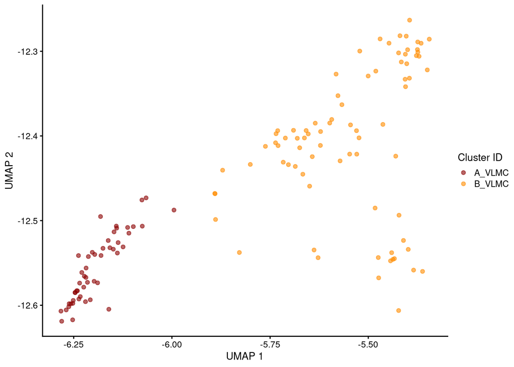

```r
sce_abm_ch.vlmc %>%
  scater::plotReducedDim(
    dimred = "UMAP",
    colour_by = "my_cluster_label"
  ) +
  scale_color_manual(
    values = my_cluster_colors %>% pull(c, x),
    name = "Cluster ID"
  )
```

```r
stopifnot(assertthat::are_equal(levels(sce_abm_ch.vlmc$my_cluster_label), c("A_VLMC", "B_VLMC")))
```

### DE genes

Identify DE genes between the two clusters within VLMC.

```r
de_results.within_vlmc <-
  sce_abm_ch.vlmc %>%
  DESeq2::DESeqDataSet(design = ~my_cluster_label) %>%
  DESeq2::estimateSizeFactors() %>%
  DESeq2::DESeq(quiet = TRUE, fitType = "local", parallel = TRUE) %>%
  DESeq2::results() %>%
  as.data.frame() %>%
  slice_min(pvalue, n = 500)
```

See as table.

```r
de_results.within_vlmc %>%
  select(mean = baseMean, l2fc = log2FoldChange, p = pvalue, padj = padj) %>%
  ind2col("symbol") %>%
  mutate(symbol = link(symbol)) %>%
  DT::datatable(escape = FALSE) %>%
  DT::formatSignif(c("mean", "l2fc", "p", "padj"), digits = 3)
```

|  | symbol | mean | l2fc | p | padj |
| --- | --- | --- | --- | --- | --- |
| 1 | Trpm3 | 6.8339537560796 | 5.48052277370716 | 3.74941788593747e-18 | 4.2030974501359e-15 |
| 2 | Alcam | 4.2962506037947 | 2.96707273932819 | 1.159663272586e-16 | 6.49991264284452e-14 |
| 3 | Ptgds | 43.1696791337573 | 3.56732337084144 | 1.4721117590388e-15 | 5.26902654351743e-13 |
| 4 | Adam12 | 1.59371846639786 | 3.2544916704138 | 1.88011651865029e-15 | 5.26902654351743e-13 |
| 5 | Nnat | 3.32004886115165 | 3.61560878500761 | 1.25899139176576e-14 | 2.82265870033884e-12 |
| 6 | Col15a1 | 0.721522533963822 | -2.77621104678058 | 1.80263090677876e-14 | 3.36791541083166e-12 |
| 7 | Fmod | 2.20611663406403 | 2.65488101057054 | 2.53168264205646e-14 | 4.05430891677899e-12 |
| 8 | Gjb2 | 1.43454232538886 | 2.58018772517995 | 3.50755815668063e-14 | 4.91496586704873e-12 |
| 9 | Itih5 | 2.79088207717431 | -1.96994668078432 | 4.99359370410809e-14 | 6.21979838033908e-12 |
| 10 | Rbp1 | 1.54002140647049 | 2.47960040836255 | 8.89382791105405e-14 | 9.96998108829159e-12 |

[output cut: 490 more lines]

Heatmap of a few top DE genes, annotated by the inferred cluster and the available cell type info.

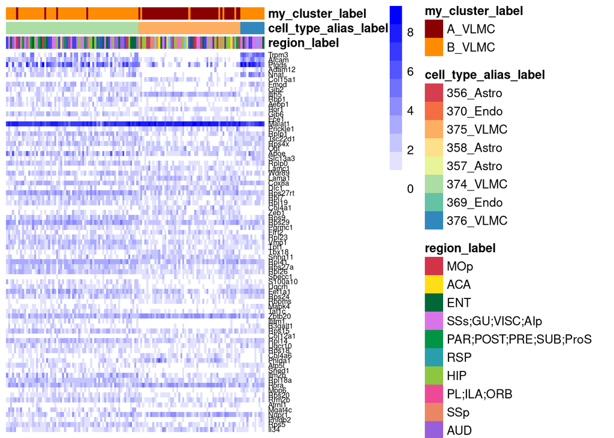

```r
de_results.within_vlmc %>%
  slice_min(pvalue, n = 77) %>%
  rownames() %>%
  rows.of(sce_abm_ch.vlmc) %>%
  `[`(, order((.)$cell_type_alias_label)) %>%
  {
    pheatmap::pheatmap(
      mat = (
        (.)@assays@data$logcounts
      ),
      annotation_col = (
        (.)@colData %>%
          as.data.frame() %>%
          # of possible interest also: region_label
          dplyr::select(region_label, cell_type_alias_label, my_cluster_label)
      ),
      cluster_cols = FALSE,
      cluster_rows = FALSE,
      show_colnames = FALSE,
      fontsize_row = 6,
      treeheight_row = 0,
      treeheight_col = 0,
      color = grDevices::colorRampPalette(c("white", "blue"))(10),
      annotation_colors = annotation_colors
    )
  }
```

In context: show all cells along the within-VLMC-DE genes.

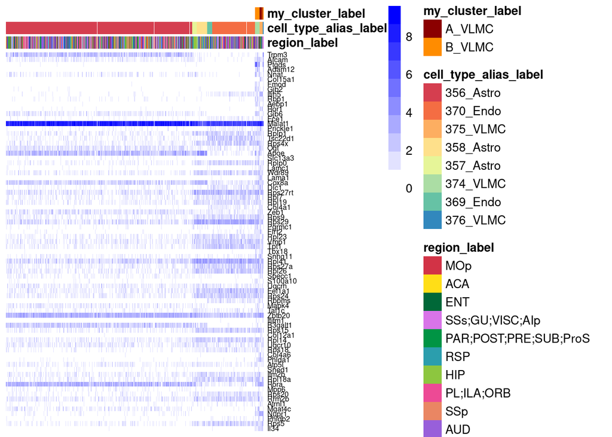

```r
sce_abm_ch$my_cluster_label <-
  sce_abm_ch.vlmc@colData %>%
  as.data.frame() %>%
  select(my_cluster_label) %>%
  `[`(colnames(sce_abm_ch), )

de_results.within_vlmc %>%
  slice_min(pvalue, n = 77) %>%
  rownames() %>%
  rows.of(sce_abm_ch) %>%
  `[`(, order((.)$cell_type_alias_label)) %>%
  {
    pheatmap::pheatmap(
      mat = (
        (.)@assays@data$logcounts
      ),
      annotation_col = (
        (.)@colData %>%
          as.data.frame() %>%
          # of possible interest also: region_label
          dplyr::select(region_label, cell_type_alias_label, my_cluster_label)
      ),
      cluster_cols = FALSE,
      cluster_rows = FALSE,
      show_colnames = FALSE,
      fontsize_row = 6,
      treeheight_row = 0,
      treeheight_col = 0,
      color = grDevices::colorRampPalette(c("white", "blue"))(10),
      annotation_colors = annotation_colors
    )
  }
```

### Pathway / geneset enrichment: preliminaries

Formatting of the GO-terms DE table:

```r
show_go <- function(tbl) {
  tbl %>%
    dplyr::select("category", "overrep.p", "#DE", "#cat", "term", "GO") %>%
    DT::datatable(escape = FALSE) %>%
    DT::formatSignif("overrep.p", digits = 3)
}
```

We take some of the top DE (up or down) genes, which requires to set a cut-off. This impacts on the size of GO categories that will be found below.

```r
# Number of top DE genes to keep
# for pathway enrichment analysis
n <- 77

# Note: `lfc` contains NA where no DE
lfc <-
  de_results.within_vlmc %>%
  # Select top DE genes
  slice_min(padj, n = n, with_ties = TRUE) %>%
  # Focus on this column
  select(lfc = log2FoldChange) %>%
  # Rownames as `symbol` column
  ind2col("symbol") %>%
  # Attach all the other symbols
  add_row(symbol = rownames(sce_abm_ch)) %>%
  # Keeps only the first one
  distinct(symbol, .keep_all = TRUE) %>%
  # As named vector (for goseq)
  pull(lfc, symbol)

stopifnot(assertthat::are_equal(length(lfc), nrow(sce_abm_ch)))
stopifnot(assertthat::are_equal(sum(na.omit(lfc < 0)) + sum(na.omit(0 < lfc)), n))
```

### GO enrichment with [goseq::goseq](https://www.bioconductor.org/packages/release/bioc/vignettes/goseq/inst/doc/goseq.pdf)

#### Compute

To find enriched GO terms with goseq we need to provide it with a list of genes as a binary vector (the fold-change is ignored).

```r
enriched_terms <-
  list(
    up = (lfc > 0),
    dn = (lfc < 0)
  ) %>% lapply(
    unattach_packages(function(.) {
      (.) %>%
        # goseq-friendly:
        tidyr::replace_na(replace = 0) %>%
        # goseq::nullp takes a binary vector (DE=1, else=0) named by gene IDs
        goseq::nullp(
          id = "geneSymbol",
          genome = "mm39",
          bias.data = (
            # Gene -to- transcript length
            # Make a vector of same shape as the named indicator vector
            # Note: this could return NULL if the column does not exist,
            #       so goseq will attempt to download the info from UCSC
            tx$mm[names(.), "tx_len"]
          ),
          plot.fit = FALSE
        ) %>%
        # forward the resulting "Probability Weighting Function"
        goseq::goseq(id = "geneSymbol", genome = "mm39") %>%
        # need to be explicit because goseq does `library(...)`
        dplyr::slice_min(over_represented_pvalue, n = 500) %>%
        dplyr::select(-under_represented_pvalue) %>%
        #
        dplyr::mutate(category = link(category)) %>%
        dplyr::rename(
          # new name = old name
          "overrep.p" = over_represented_pvalue,
          "#cat" = numInCat,
          "#DE" = numDEInCat,
          "GO" = ontology
        )
    })
  )
```

#### Up

```r
enriched_terms$up %>% show_go()
```

|  | category | overrep.p | #DE | #cat | term | GO |
| --- | --- | --- | --- | --- | --- | --- |
| 1 | GO:0003735 | 0 | 18 | 148 | structural constituent of ribosome | MF |
| 2 | GO:0005198 | 0 | 18 | 564 | structural molecule activity | MF |
| 3 | GO:0005840 | 0 | 18 | 218 | ribosome | CC |
| 4 | GO:0006412 | 0 | 19 | 564 | translation | BP |
| 5 | GO:0022626 | 0 | 17 | 105 | cytosolic ribosome | CC |
| 6 | GO:0022627 | 0 | 9 | 45 | cytosolic small ribosomal subunit | CC |
| 7 | GO:0043043 | 0 | 19 | 586 | peptide biosynthetic process | BP |
| 8 | GO:0044391 | 0 | 17 | 184 | ribosomal subunit | CC |
| 9 | GO:1990904 | 0 | 17 | 674 | ribonucleoprotein complex | CC |
| 10 | GO:0006518 | 6.43843711388208e-17 | 21 | 729 | peptide metabolic process | BP |

[output cut: 491 more lines]

#### Down

```r
enriched_terms$dn %>% show_go()
```

|  | category | overrep.p | #DE | #cat | term | GO |
| --- | --- | --- | --- | --- | --- | --- |
| 1 | GO:0005604 | 1.02755590166117e-07 | 6 | 113 | basement membrane | CC |
| 2 | GO:0062023 | 1.25635312248952e-07 | 8 | 381 | collagen-containing extracellular matrix | CC |
| 3 | GO:0005201 | 5.51707995364695e-07 | 6 | 147 | extracellular matrix structural constituent | MF |
| 4 | GO:0031012 | 1.07839402383069e-06 | 8 | 505 | extracellular matrix | CC |
| 5 | GO:0030020 | 2.9089593778033e-06 | 4 | 38 | extracellular matrix structural constituent conferring tensile strength | MF |
| 6 | GO:0005581 | 1.36638806748781e-05 | 4 | 81 | collagen trimer | CC |
| 7 | GO:0005606 | 3.07727333979943e-05 | 2 | 3 | laminin-1 complex | CC |
| 8 | GO:0006110 | 5.11379008636209e-05 | 3 | 47 | regulation of glycolytic process | BP |
| 9 | GO:0072359 | 5.23773683553748e-05 | 9 | 1136 | circulatory system development | BP |
| 10 | GO:0061304 | 6.16365427974385e-05 | 2 | 5 | retinal blood vessel morphogenesis | BP |

[output cut: 490 more lines]

### GO enrichment with [limma::goana](https://www.bioconductor.org/packages/devel/workflows/vignettes/RnaSeqGeneEdgeRQL/inst/doc/edgeRQL.html#pathway-analysis)

#### Compute

```r
enriched_terms <-
  list(
    up = (lfc > 0),
    dn = (lfc < 0)
  ) %>% lapply(
    function(.) {
      data.frame(take = .) %>%
        filter(take == TRUE) %>%
        ind2col("symbol") %>%
        # Get the Entrez IDs of our genes
        merge(
          org.Mm.eg.db::org.Mm.egSYMBOL2EG %>% as.data.frame(),
          by = "symbol"
        ) %>%
        pull(gene_id) %>%
        # Enrichment analysis
        limma::goana(species = "Mm") %>%
        # Select topmost
        dplyr::slice_min(P.DE, n = 500) %>%
        # Format for display
        ind2col("category") %>%
        dplyr::mutate(category = link(category)) %>%
        dplyr::rename(
          # new name = old name
          "overrep.p" = P.DE,
          "#DE" = DE,
          "#cat" = N,
          "GO" = Ont,
          "term" = Term
        )
    }
  )
```

#### Up

```r
enriched_terms$up %>% show_go()
```

|  | category | overrep.p | #DE | #cat | term | GO |
| --- | --- | --- | --- | --- | --- | --- |
| 1 | GO:0022626 | 8.86557834128304e-36 | 22 | 115 | cytosolic ribosome | CC |
| 2 | GO:0003735 | 1.74131224401424e-34 | 23 | 158 | structural constituent of ribosome | MF |
| 3 | GO:0005840 | 2.26042850186522e-30 | 23 | 234 | ribosome | CC |
| 4 | GO:0044391 | 3.04717042477481e-30 | 22 | 198 | ribosomal subunit | CC |
| 5 | GO:0005198 | 1.45003811660213e-28 | 28 | 576 | structural molecule activity | MF |
| 6 | GO:0022627 | 2.18611962719515e-28 | 15 | 46 | cytosolic small ribosomal subunit | CC |
| 7 | GO:0015935 | 1.75382663890791e-24 | 15 | 78 | small ribosomal subunit | CC |
| 8 | GO:0006412 | 1.65818931860388e-20 | 23 | 627 | translation | BP |
| 9 | GO:0043043 | 3.58063887407227e-20 | 23 | 649 | peptide biosynthetic process | BP |
| 10 | GO:0043604 | 6.69339997421795e-20 | 24 | 761 | amide biosynthetic process | BP |

[output cut: 498 more lines]

#### Down

```r
enriched_terms$dn %>% show_go()
```

|  | category | overrep.p | #DE | #cat | term | GO |
| --- | --- | --- | --- | --- | --- | --- |
| 1 | GO:0010996 | 8.87224174992692e-08 | 3 | 23 | response to auditory stimulus | BP |
| 2 | GO:0005314 | 9.15712660925618e-07 | 2 | 4 | high-affinity glutamate transmembrane transporter activity | MF |
| 3 | GO:0015501 | 9.15712660925618e-07 | 2 | 4 | glutamate:sodium symporter activity | MF |
| 4 | GO:0070777 | 1.52585248280266e-06 | 2 | 5 | D-aspartate transport | BP |
| 5 | GO:0070779 | 1.52585248280266e-06 | 2 | 5 | D-aspartate import across plasma membrane | BP |
| 6 | GO:0017153 | 2.28827590486271e-06 | 2 | 6 | sodium:dicarboxylate symporter activity | MF |
| 7 | GO:0030054 | 3.03847157958911e-06 | 7 | 2065 | cell junction | CC |
| 8 | GO:0042940 | 4.26957177248071e-06 | 2 | 8 | D-amino acid transport | BP |
| 9 | GO:0007610 | 5.79631105977065e-06 | 5 | 741 | behavior | BP |
| 10 | GO:0045202 | 7.68742668122514e-06 | 6 | 1451 | synapse | CC |

[output cut: 490 more lines]

### KEGG enrichment with [limma::kegga](https://www.bioconductor.org/packages/devel/workflows/vignettes/RnaSeqGeneEdgeRQL/inst/doc/edgeRQL.html#pathway-analysis)

#### Compute

```r
enriched_terms <-
  list(
    up = (lfc > 0),
    dn = (lfc < 0)
  ) %>% lapply(
    function(.) {
      data.frame(take = .) %>%
        filter(take == TRUE) %>%
        ind2col("symbol") %>%
        # Get the Entrez IDs of our genes
        merge(
          org.Mm.eg.db::org.Mm.egSYMBOL2EG %>% as.data.frame(),
          by = "symbol"
        ) %>%
        pull(gene_id) %>%
        # Enrichment analysis
        limma::kegga(species = "Mm") %>%
        # https://www.bioconductor.org/packages/devel/workflows/vignettes/RnaSeqGeneEdgeRQL/inst/doc/edgeRQL.html#pathway-analysis
        limma::topKEGG(n = 30, truncate = 34)
    }
  )
```

#### Up

```r
enriched_terms$up
```

```
##                                          Pathway   N DE         P.DE
## path:mmu03010                           Ribosome 179 23 1.479474e-28
## path:mmu05171     Coronavirus disease - COVID-19 247 23 3.190087e-25
## path:mmu04914 Progesterone-mediated oocyte ma...  90  3 9.178243e-03
## path:mmu04066            HIF-1 signaling pathway 114  3 1.734642e-02
## path:mmu04015             Rap1 signaling pathway 214  4 1.918736e-02
## path:mmu04730               Long-term depression  60  2 3.372092e-02
## path:mmu04520                  Adherens junction  71  2 4.580017e-02
## path:mmu01521 EGFR tyrosine kinase inhibitor ...  79  2 5.543745e-02
## path:mmu04612 Antigen processing and presenta...  90  2 6.973006e-02
## path:mmu05215                    Prostate cancer  99  2 8.222306e-02
## path:mmu04151         PI3K-Akt signaling pathway 359  4 9.347831e-02
## path:mmu04014              Ras signaling pathway 232  3 1.006163e-01
## path:mmu04670 Leukocyte transendothelial migr... 118  2 1.105897e-01
## path:mmu04071     Sphingolipid signaling pathway 124  2 1.200261e-01
## path:mmu04726               Serotonergic synapse 131  2 1.312814e-01
## path:mmu04915         Estrogen signaling pathway 134  2 1.361796e-01
## path:mmu04371           Apelin signaling pathway 137  2 1.411192e-01
## path:mmu04140                 Autophagy - animal 138  2 1.427746e-01
## path:mmu04550 Signaling pathways regulating p... 140  2 1.460982e-01
## path:mmu04150             mTOR signaling pathway 156  2 1.732332e-01
## path:mmu04514            Cell adhesion molecules 174  2 2.046671e-01
## path:mmu05030                  Cocaine addiction  48  1 2.076260e-01
## path:mmu00600            Sphingolipid metabolism  50  1 2.152938e-01
## path:mmu04360                      Axon guidance 181  2 2.170748e-01
## path:mmu04978                 Mineral absorption  53  1 2.266598e-01
## path:mmu04923 Regulation of lipolysis in adip...  56  1 2.378649e-01
## path:mmu04510                     Focal adhesion 201  2 2.528657e-01
## path:mmu05134                      Legionellosis  61  1 2.561887e-01
## path:mmu04213 Longevity regulating pathway - ...  62  1 2.598015e-01
## path:mmu05205            Proteoglycans in cancer 205  2 2.600595e-01
```

#### Down

```r
enriched_terms$dn
```

```
##                                          Pathway   N DE         P.DE
## path:mmu04721             Synaptic vesicle cycle  77  2 0.0004369922
## path:mmu04724              Glutamatergic synapse 113  2 0.0009399664
## path:mmu05016                 Huntington disease 302  2 0.0065605660
## path:mmu04964 Proximal tubule bicarbonate rec...  22  1 0.0098372738
## path:mmu04960 Aldosterone-regulated sodium re...  38  1 0.0169459349
## path:mmu04973 Carbohydrate digestion and abso...  48  1 0.0213693671
## path:mmu04978                 Mineral absorption  53  1 0.0235754768
## path:mmu04961 Endocrine and other factor-regu...  61  1 0.0270974915
## path:mmu04918          Thyroid hormone synthesis  74  1 0.0328004331
## path:mmu04971             Gastric acid secretion  75  1 0.0332380800
## path:mmu04911                  Insulin secretion  86  1 0.0380423993
## path:mmu04970                 Salivary secretion  86  1 0.0380423993
## path:mmu04260         Cardiac muscle contraction  87  1 0.0384782659
## path:mmu04976                     Bile secretion 100  1 0.0441310636
## path:mmu04925 Aldosterone synthesis and secre... 102  1 0.0449985074
## path:mmu04974 Protein digestion and absorptio... 108  1 0.0475972968
## path:mmu04972               Pancreatic secretion 114  1 0.0501907786
## path:mmu04919 Thyroid hormone signaling pathw... 120  1 0.0527789601
## path:mmu04261 Adrenergic signaling in cardiom... 152  1 0.0664933761
## path:mmu04022         cGMP-PKG signaling pathway 173  1 0.0754121655
## path:mmu04514            Cell adhesion molecules 174  1 0.0758352694
## path:mmu04024             cAMP signaling pathway 215  1 0.0930578679
## path:mmu05014      Amyotrophic lateral sclerosis 369  1 0.1556060316
## path:mmu00472 D-Arginine and D-ornithine meta...   1  0 1.0000000000
## path:mmu00780                  Biotin metabolism   3  0 1.0000000000
## path:mmu00471 D-Glutamine and D-glutamate met...   4  0 1.0000000000
## path:mmu00785             Lipoic acid metabolism   4  0 1.0000000000
## path:mmu00290 Valine, leucine and isoleucine ...   4  0 1.0000000000
## path:mmu00524 Neomycin, kanamycin and gentami...   5  0 1.0000000000
## path:mmu00232                Caffeine metabolism   6  0 1.0000000000
```